# Explainig the code

```python
import pandas as pd
import numpy as np
import matplotlib.pyplot as plt
import seaborn as sns
from sklearn.tree import DecisionTreeRegressor
from sklearn.model_selection import train_test_split
from sklearn.preprocessing import LabelEncoder
from sklearn.preprocessing import OneHotEncoder
```

pandas is used to handle and manipulate data. numpy is used to work with arrays and perform mathematical operations. matplotlib is a plotting library used to visualize data. seaborn is a visualization library built on top of matplotlib. DecisionTreeRegressor is a decision tree-based regression algorithm provided by scikit-learn. train_test_split is a function from scikit-learn used to split the data into training and testing datasets. LabelEncoder and OneHotEncoder are classes from scikit-learn used to encode categorical features.

```python
df = pd.read_csv('Salary Data.csv')
df.head(10)
```

|  | Age | Gender | Education Level | Job Title | Years of Experience | Salary |
| --- | --- | --- | --- | --- | --- | --- |
| 0 | 32.0 | Male | Bachelor's | Software Engineer | 5.0 | 90000.0 |
| 1 | 28.0 | Female | Master's | Data Analyst | 3.0 | 65000.0 |
| 2 | 45.0 | Male | PhD | Senior Manager | 15.0 | 150000.0 |
| 3 | 36.0 | Female | Bachelor's | Sales Associate | 7.0 | 60000.0 |
| 4 | 52.0 | Male | Master's | Director | 20.0 | 200000.0 |
| 5 | 29.0 | Male | Bachelor's | Marketing Analyst | 2.0 | 55000.0 |
| 6 | 42.0 | Female | Master's | Product Manager | 12.0 | 120000.0 |
| 7 | 31.0 | Male | Bachelor's | Sales Manager | 4.0 | 80000.0 |
| 8 | 26.0 | Female | Bachelor's | Marketing Coordinator | 1.0 | 45000.0 |
| 9 | 38.0 | Male | PhD | Senior Scientist | 10.0 | 110000.0 |

pd.read_csv reads the CSV file 'Salary Data.csv' and stores it in a pandas DataFrame df. df.head(10) displays the first 10 rows of the DataFrame.

```python
df.info()
```

```
<class 'pandas.core.frame.DataFrame'>
RangeIndex: 375 entries, 0 to 374
Data columns (total 6 columns):
 #   Column               Non-Null Count  Dtype
---  ------               --------------  -----
 0   Age                  373 non-null    float64
 1   Gender               373 non-null    object
 2   Education Level      373 non-null    object
 3   Job Title            373 non-null    object
 4   Years of Experience  373 non-null    float64
 5   Salary               373 non-null    float64
dtypes: float64(3), object(3)
memory usage: 17.7+ KB
```

df.info() provides information about the DataFrame such as the number of rows, columns, column data types, and missing values.

```python
df.dropna(inplace=True)
df.drop_duplicates()
df.info()
```

```
<class 'pandas.core.frame.DataFrame'>
Int64Index: 373 entries, 0 to 374
Data columns (total 6 columns):
 #   Column               Non-Null Count  Dtype
---  ------               --------------  -----
 0   Age                  373 non-null    float64
 1   Gender               373 non-null    object
 2   Education Level      373 non-null    object
 3   Job Title            373 non-null    object
 4   Years of Experience  373 non-null    float64
 5   Salary               373 non-null    float64
dtypes: float64(3), object(3)
memory usage: 20.4+ KB
```

```python
df['Gender'].unique()
gender_label = LabelEncoder()
df['Gender']=gender_label.fit_transform(df['Gender'])
df.head()
```

|  | Age | Gender | Education Level | Job Title | Years of Experience | Salary |
| --- | --- | --- | --- | --- | --- | --- |
| 0 | 32.0 | 1 | Bachelor's | Software Engineer | 5.0 | 90000.0 |
| 1 | 28.0 | 0 | Master's | Data Analyst | 3.0 | 65000.0 |
| 2 | 45.0 | 1 | PhD | Senior Manager | 15.0 | 150000.0 |
| 3 | 36.0 | 0 | Bachelor's | Sales Associate | 7.0 | 60000.0 |
| 4 | 52.0 | 1 | Master's | Director | 20.0 | 200000.0 |

df['Gender'].unique() displays the unique values in the 'Gender' column of the DataFrame. gender_label = LabelEncoder() creates an instance of the LabelEncoder class for encoding categorical features. df.head() displays the first five rows of the updated DataFrame.

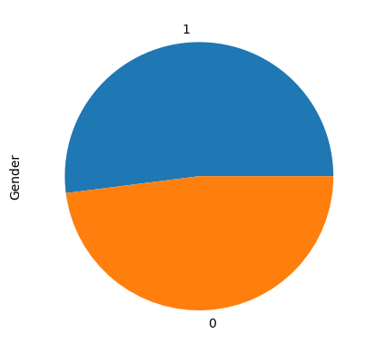

```python
df['Gender'].value_counts().plot(kind='pie')
```

df['Gender'].value_counts().plot(kind='pie') creates a pie chart of the count of each value in the 'Gender' column.

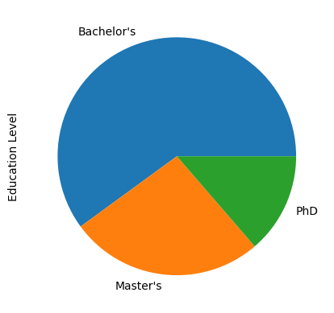

```python
df['Education Level'].value_counts().plot(kind='pie')
```

df['Education Level'].value_counts().plot(kind='pie') creates a pie chart of the count of each value in the 'Education Level' column.

```python
edu_label_encoder = LabelEncoder()
df['Education Level'] = edu_label_encoder.fit_transform(df['Education Level'])
job_title_encoder = LabelEncoder()
df['Job Title']=job_title_encoder.fit_transform(df['Job Title'])
df.head()
```

|  | Age | Gender | Education Level | Job Title | Years of Experience | Salary |
| --- | --- | --- | --- | --- | --- | --- |
| 0 | 32.0 | 1 | 0 | 159 | 5.0 | 90000.0 |
| 1 | 28.0 | 0 | 1 | 17 | 3.0 | 65000.0 |
| 2 | 45.0 | 1 | 2 | 130 | 15.0 | 150000.0 |
| 3 | 36.0 | 0 | 0 | 101 | 7.0 | 60000.0 |
| 4 | 52.0 | 1 | 1 | 22 | 20.0 | 200000.0 |

edu_label_encoder = LabelEncoder() creates an instance of the LabelEncoder class for encoding categorical features.

df['Education Level'] = edu_label_encoder.fit_transform(df['Education Level']) encodes the 'Education Level' column of the DataFrame using the fit_transform() method of the LabelEncoder object.

job_title_encoder = LabelEncoder() creates an instance of the LabelEncoder class for encoding categorical features.

df['Job Title']=job_title_encoder.fit_transform(df['Job Title']) encodes the 'Job Title' column of the DataFrame using the fit_transform() method of the LabelEncoder object.

df.head() displays the first five rows of the updated DataFrame.

```python
Y = df['Salary']
X = df.drop(['Salary'], axis=1)
x_train, x_test, y_train, y_test = train_test_split(X, Y, test_size=0.2, random_state=123)
model=DecisionTreeRegressor(max_depth=5)
model.fit(x_train, y_train)
print(model.score(x_test, y_test)*100)
```

```
92.96131493199641
```

Y = df['Salary']: This line extracts the 'Salary' column from the DataFrame and assigns it to the variable Y, which will be used as the target variable for the model.

X = df.drop(['Salary'], axis=1): This line creates a new DataFrame X that contains all the columns except the 'Salary' column. This will be used as the input features for the model.

x_train, x_test, y_train, y_test = train_test_split(X, Y, test_size=0.2, random_state=123): This line splits the data into training and testing sets. The X and Y data are split into x_train, x_test, y_train, and y_test. The test_size parameter specifies the percentage of data to use for testing, and the random_state parameter ensures that the split is reproducible.

model=DecisionTreeRegressor(max_depth=5): This line creates an instance of the DecisionTreeRegressor class from scikit-learn's tree module. The max_depth parameter is set to 5, which limits the maximum depth of the tree to 5 levels. This helps to prevent overfitting and improve the generalization of the model.

model.fit(x_train, y_train): This line fits the decision tree model to the training data.

print(model.score(x_test, y_test)*100): This line prints the R^2 score of the model on the testing data, which is a measure of how well the model fits the data. The score is multiplied by 100 to convert it to a percentage. The R^2 score ranges from 0 to 1, with higher values indicating a better fit.

```python
from sklearn import metrics
y_pred = model.predict(x_test)
print('r2 : ', metrics.r2_score(y_pred, y_test)*100)
```

```
r2 :  92.1147709785247
```

using the metrics module from sklearn library to calculate the R-squared score for the decision tree regression model.

and The code then prints the R-squared score multiplied by 100 to get the percentage value of the score.

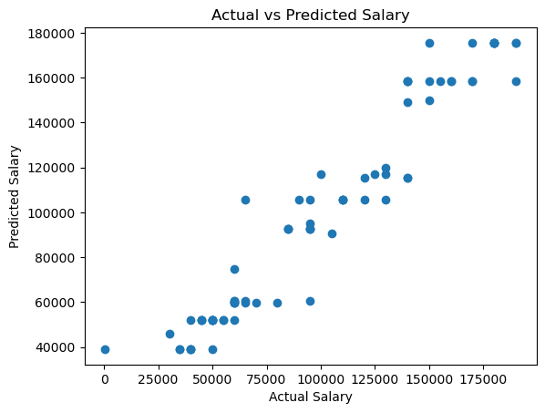

```python
plt.scatter(y_test, y_pred)
plt.xlabel('Actual Salary')
plt.ylabel('Predicted Salary')
plt.title('Actual vs Predicted Salary')
plt.show()
```

This part of the code creates a scatter plot to visualize the predicted versus actual salary values.

The plt.scatter() function is used to create the scatter plot, with the actual salary values (y_test) on the x-axis and predicted salary values (y_pred) on the y-axis. The xlabel() and ylabel() functions are used to label the x and y axes, respectively, and the title() function is used to give the plot a title.

Finally, the show() function is called to display the plot.